# Assignment 4: Building Features, Watching What Happens

- Show All Code
- Hide All Code
- View Source

Predicting households without a vehicle in Philadelphia

ACS reliability, spatial features, and cross-validated predictions of tract-level vehicle availability.

Author

Oscar Luo

Published

October 5, 2026

Modified

October 16, 2026

## Part 0: Setup

```r
library(tidyverse)
library(tidycensus)
library(sf)
library(caret)
library(gt)

options(timeout = 300, tigris_use_cache = TRUE)
theme_set(theme_minimal(base_size = 12))
knitr::opts_chunk$set(fig.width = 8, fig.height = 5, dpi = 160)

# The project executes from its root, as specified in _quarto.yml.
# Saved API responses allow this document to render without downloading again.
data_dir <- "data/assignment4"
dir.create(data_dir, recursive = TRUE, showWarnings = FALSE)
Sys.getenv("CENSUS_API_KEY") != ""  # Read the key without displaying it.
```

```
[1] TRUE
```

### Cross-validation and model log

```r
ctrl <- trainControl(method = "cv", number = 10)

cv_rmse <- function(formula, data) {
  df <- if (inherits(data, "sf")) st_drop_geometry(data) else data
  vars <- all.vars(formula)
  bad <- vars[sapply(vars, function(v) any(is.na(df[[v]])))]
  if (length(bad) > 0) {
    stop("These variables have NAs: ", paste(bad, collapse = ", "),
         ". Fill them or choose another variable (Rule 1: don't drop rows).")
  }
  set.seed(5080)
  fit <- train(formula, data = df, method = "lm", trControl = ctrl)
  fit$results$RMSE
}

model_log <- tibble(
  model = character(), added = character(), cv_rmse = numeric(),
  notes = character()
)
```

## Part 1: Choose the outcome

### 1A: Pull the outcome and baseline predictors

The outcome is the percentage of households without a vehicle, using the [2023 ACS B08201 definitions](https://api.census.gov/data/2023/acs/acs5/groups/B08201.html).

| Variable | ACS source | Reason for including it |
| --- | --- | --- |
| No-vehicle household share, `y` | B08201_002 / B08201_001 × 100 | Transportation access outcome |
| Income per $10,000, `income_10k` | B19013_001 / 10,000 | Resources available for vehicle ownership |
| Renter share, `pct_renter` | B25003_003 / B25003_001 × 100 | Tenure and housing-market context |
| Bachelor’s degree or higher, `pct_ba` | Sum of B15003_022–025 / B15003_001 × 100 | Education and socioeconomic composition |
| Average household size, `hh_size` | B25010_001 | Household transportation needs and shared resources |

None of the four predictors is derived from vehicle availability.

```r
acs_vars <- c(
  total_pop = "B01003_001",
  households = "B08201_001", no_vehicle = "B08201_002",
  med_inc = "B19013_001",
  occ_units = "B25003_001", renter_occ = "B25003_003",
  edu_total = "B15003_001", ba = "B15003_022", ma = "B15003_023",
  prof = "B15003_024", phd = "B15003_025",
  hh_size = "B25010_001"
)

metadata_file <- file.path(data_dir, "variable_metadata.rds")
if (!file.exists(metadata_file)) {
  variable_metadata <- load_variables(2023, "acs5") %>%
    filter(name %in% acs_vars)
  saveRDS(variable_metadata, metadata_file)
}
variable_metadata <- readRDS(metadata_file)
variable_metadata %>% select(name, label) %>% knitr::kable()
```

| name | label |
| --- | --- |
| B01003_001 | Estimate!!Total |
| B08201_001 | Estimate!!Total: |
| B08201_002 | Estimate!!Total:!!No vehicle available |
| B15003_001 | Estimate!!Total: |
| B15003_022 | Estimate!!Total:!!Bachelor’s degree |
| B15003_023 | Estimate!!Total:!!Master’s degree |
| B15003_024 | Estimate!!Total:!!Professional school degree |
| B15003_025 | Estimate!!Total:!!Doctorate degree |
| B19013_001 | Estimate!!Median household income in the past 12 months (in 2023 inflation-adjusted dollars) |
| B25003_001 | Estimate!!Total: |
| B25003_003 | Estimate!!Total:!!Renter occupied |
| B25010_001 | Estimate!!Average household size –!!Total: |

```r
acs_file <- file.path(data_dir, "acs_2023_tracts.rds")
if (!file.exists(acs_file)) {
  philly_tracts <- get_acs(
    geography = "tract", state = "PA", county = "Philadelphia",
    variables = acs_vars, year = 2023, survey = "acs5",
    output = "wide", geometry = TRUE
  ) %>% st_transform(2272)
  saveRDS(philly_tracts, acs_file)
}
philly_tracts <- readRDS(acs_file)
```

```r
philly_tracts <- philly_tracts %>%
  mutate(
    y = if_else(householdsE > 0, no_vehicleE / householdsE * 100, NA_real_),
    y_moe = if_else(
      householdsE > 0,
      moe_prop(no_vehicleE, householdsE, no_vehicleM, householdsM) * 100,
      NA_real_
    ),
    y_cv = if_else(y > 0, (y_moe / 1.645) / y * 100, NA_real_),
    income_10k = med_incE / 10000,
    pct_renter = renter_occE / occ_unitsE * 100,
    pct_ba = (baE + maE + profE + phdE) / edu_totalE * 100,
    hh_size = hh_sizeE,
    reliability = case_when(
      is.na(y) ~ "Missing outcome",
      is.na(y_cv) ~ "Undefined CV (zero estimate)",
      y_cv < 12 ~ "High",
      y_cv <= 40 ~ "Moderate",
      TRUE ~ "Low"
    )
  )
```

### 1B: Is the outcome reliable enough?

I use `moe_prop()` for the 90% margin of error. Reliability is High for CV < 12%, Moderate for 12–40%, and Low above 40%; zero estimates have undefined CV.

```r
sum(is.na(philly_tracts$y))
```

```
[1] 20
```

```r
summary(philly_tracts$y_cv)
```

```
   Min. 1st Qu.  Median    Mean 3rd Qu.    Max.     NAs
  3.572  17.201  23.397  26.254  31.875 182.123      21
```

```r
philly_tracts %>% st_drop_geometry() %>% count(reliability) %>%
  gt() %>%
  cols_label(reliability = "Reliability", n = "Tracts") %>%
  tab_header(title = "Reliability of no-vehicle household estimates",
             subtitle = "Philadelphia, 2019–2023 ACS; all 408 tracts")
```

Reliability of no-vehicle household estimates

Philadelphia, 2019–2023 ACS; all 408 tracts

| Reliability | Tracts |
| --- | --- |
| High | 29 |
| Low | 45 |
| Missing outcome | 20 |
| Moderate | 313 |
| Undefined CV (zero estimate) | 1 |

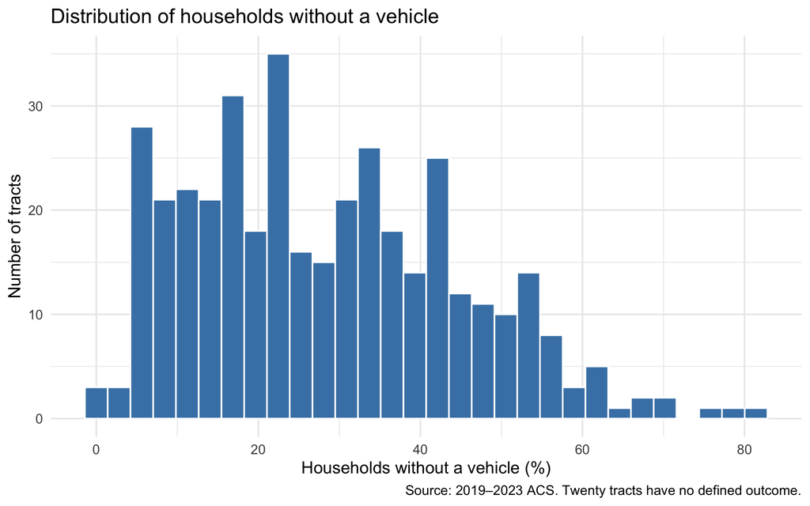

```r
ggplot(philly_tracts, aes(x = y)) +
  geom_histogram(bins = 30, fill = "steelblue", color = "white", na.rm = TRUE) +
  labs(title = "Distribution of households without a vehicle",
       x = "Households without a vehicle (%)", y = "Number of tracts",
       caption = "Source: 2019–2023 ACS. Twenty tracts have no defined outcome.")
```

No-vehicle household share informs transit and pedestrian planning. Of 408 tracts, 20 lack an outcome; the remaining 388 include 29 High-reliability, 313 Moderate, 45 Low, and one with undefined CV. Only 11.6% have Low reliability, below the one-third threshold, so I proceed.

### 1C: Decide which tracts to model

```r
tracts <- philly_tracts %>%
  filter(total_popE > 0, is.finite(y), is.finite(income_10k),
         is.finite(pct_renter), is.finite(pct_ba), is.finite(hh_size)) %>%
  arrange(GEOID)

excluded <- philly_tracts %>% st_drop_geometry() %>%
  anti_join(st_drop_geometry(tracts), by = "GEOID") %>%
  transmute(
    tract = sub(";.*", "", NAME), population = total_popE,
    households = householdsE,
    reason = case_when(
      total_popE == 0 ~ "No population or households",
      householdsE == 0 ~ "Population but no households",
      is.na(med_incE) ~ "Missing median household income",
      TRUE ~ "Other missing baseline variable"
    )
  )
excluded %>% knitr::kable()
```

| tract | population | households | reason |
| --- | --- | --- | --- |
| Census Tract 165 | 2165 | 978 | Missing median household income |
| Census Tract 9809.02 | 0 | 0 | No population or households |
| Census Tract 9808 | 0 | 0 | No population or households |
| Census Tract 285 | 2625 | 1081 | Missing median household income |
| Census Tract 369.01 | 49 | 0 | Population but no households |
| Census Tract 148 | 892 | 525 | Missing median household income |
| Census Tract 277 | 5489 | 2448 | Missing median household income |
| Census Tract 301 | 6446 | 2642 | Missing median household income |
| Census Tract 9805 | 0 | 0 | No population or households |
| Census Tract 9806 | 0 | 0 | No population or households |
| Census Tract 9891 | 1240 | 0 | Population but no households |
| Census Tract 9893 | 160 | 0 | Population but no households |
| Census Tract 9800.01 | 0 | 0 | No population or households |
| Census Tract 9800.02 | 0 | 0 | No population or households |
| Census Tract 9809.06 | 0 | 0 | No population or households |
| Census Tract 205 | 3383 | 1663 | Missing median household income |
| Census Tract 9802 | 396 | 13 | Missing median household income |
| Census Tract 9892 | 0 | 0 | No population or households |
| Census Tract 9809.01 | 0 | 0 | No population or households |
| Census Tract 9800.03 | 0 | 0 | No population or households |
| Census Tract 9807.01 | 0 | 0 | No population or households |
| Census Tract 9809.03 | 0 | 0 | No population or households |
| Census Tract 9809.05 | 0 | 0 | No population or households |
| Census Tract 9804 | 0 | 0 | No population or households |
| Census Tract 9807.02 | 0 | 0 | No population or households |
| Census Tract 9803 | 0 | 0 | No population or households |
| Census Tract 9809.04 | 0 | 0 | No population or households |

```r
tibble(all_tracts = nrow(philly_tracts), modeled = nrow(tracts),
       excluded = nrow(excluded))
```

```
# A tibble: 1 × 3
  all_tracts modeled excluded
       <int>   <int>    <int>
1        408     381       27
```

```r
# Freeze both the row order and the folds; never filter tracts again.
model_geoids <- tracts$GEOID
set.seed(5080)
folds <- createFolds(tracts$y, k = 10, returnTrain = TRUE)
ctrl <- trainControl(method = "cv", number = 10, index = folds,
                     savePredictions = "final")
stopifnot(!anyDuplicated(model_geoids), all(is.finite(tracts$y_cv)))
```

Filtering removes **27 tracts**, leaving **381**: 17 have no residents, three have residents but no households, and seven lack median income. These include nonresidential or group-quarters areas and some inhabited tracts with missing data. Low-reliability tracts remain; no rows are dropped later.

## Part 2: Baseline model

### 2A: Look first

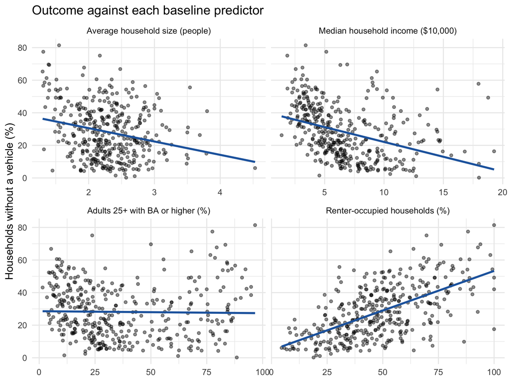

```r
predictor_labels <- c(
  income_10k = "Median household income ($10,000)",
  pct_renter = "Renter-occupied households (%)",
  pct_ba = "Adults 25+ with BA or higher (%)",
  hh_size = "Average household size (people)"
)
tracts %>% st_drop_geometry() %>%
  select(y, all_of(names(predictor_labels))) %>%
  pivot_longer(-y, names_to = "predictor", values_to = "value") %>%
  ggplot(aes(x = value, y = y)) +
  geom_point(alpha = 0.45, size = 1.3) +
  geom_smooth(method = "lm", se = FALSE, color = "#2166ac") +
  facet_wrap(~predictor, scales = "free_x",
             labeller = as_labeller(predictor_labels)) +
  labs(title = "Outcome against each baseline predictor",
       x = NULL, y = "Households without a vehicle (%)")
```

Renter share is positively associated with the outcome; income and household size generally slope downward. Education has little overall linear association.

### 2B: Fit and log

```r
f1 <- y ~ income_10k + pct_renter + pct_ba + hh_size
m1 <- lm(f1, data = tracts)
summary(m1)
```

```
Call:
lm(formula = f1, data = tracts)

Residuals:
    Min      1Q  Median      3Q     Max
-36.493  -8.459  -1.188   8.417  43.278

Coefficients:
            Estimate Std. Error t value Pr(>|t|)
(Intercept) 28.23367    5.98803   4.715 3.41e-06 ***
income_10k  -1.69023    0.38395  -4.402 1.40e-05 ***
pct_renter   0.37003    0.04238   8.731  < 2e-16 ***
pct_ba       0.04767    0.05618   0.849    0.397
hh_size     -3.65696    1.83540  -1.992    0.047 *
---
Signif. codes:  0 '***' 0.001 '**' 0.01 '*' 0.05 '.' 0.1 ' ' 1

Residual standard error: 12.32 on 376 degrees of freedom
Multiple R-squared:  0.434, Adjusted R-squared:  0.4279
F-statistic: 72.07 on 4 and 376 DF,  p-value: < 2.2e-16
```

```r
model_log <- model_log %>%
  add_row(model = "m1", added = "Four ACS predictors",
          cv_rmse = cv_rmse(f1, tracts), notes = "Baseline")
model_log
```

```
# A tibble: 1 × 4
  model added               cv_rmse notes
  <chr> <chr>                 <dbl> <chr>
1 m1    Four ACS predictors    12.3 Baseline
```

On tracts it has not seen, the baseline model misses by about **12.33 percentage points**, measured by mean ten-fold RMSE.

### 2C: Where is the baseline wrong?

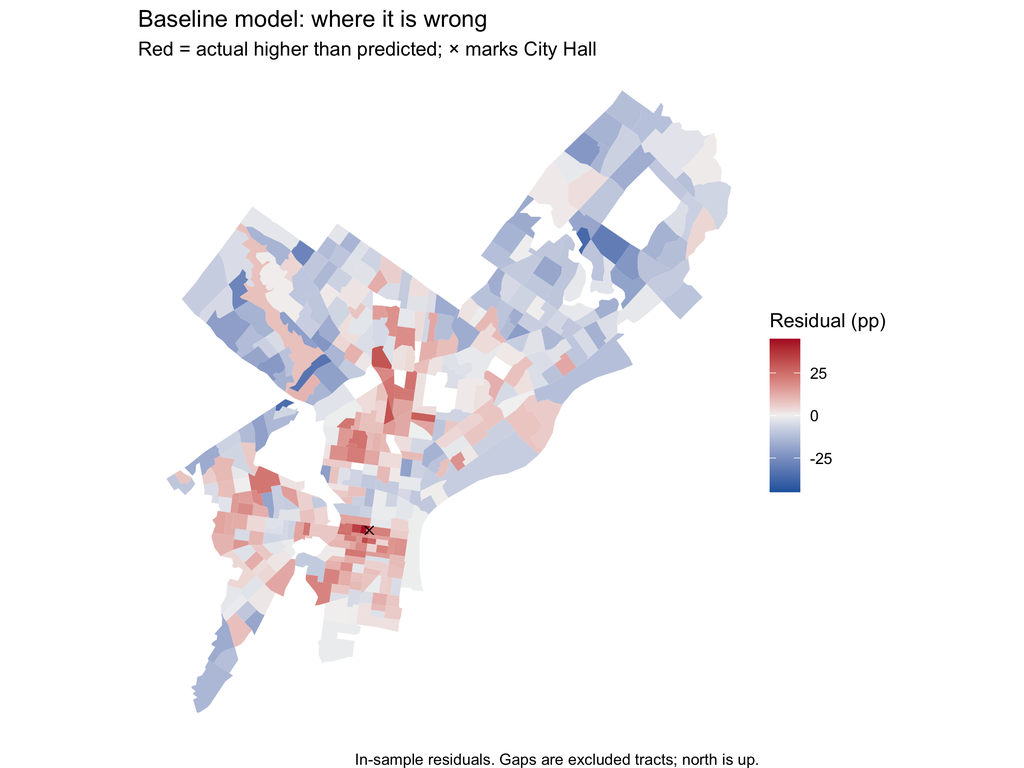

```r
tracts <- tracts %>% mutate(resid_m1 = residuals(m1))

city_hall <- st_sfc(st_point(c(-75.1636, 39.9526)), crs = 4326) %>%
  st_transform(st_crs(tracts))

ggplot(tracts) +
  geom_sf(aes(fill = resid_m1), color = NA) +
  geom_sf(data = city_hall, shape = 4, size = 2, inherit.aes = FALSE) +
  scale_fill_gradient2(low = "#2166ac", mid = "grey95", high = "#b2182b",
                       midpoint = 0, limits = c(-45, 45)) +
  theme_void() +
  labs(title = "Baseline model: where it is wrong",
       subtitle = "Red = actual higher than predicted; × marks City Hall",
       fill = "Residual (pp)",
       caption = "In-sample residuals. Gaps are excluded tracts; north is up.")
```

Underprediction clusters around Center City and parts of North and West Philadelphia; overprediction is common in the Northeast and northwest. Missing centrality, street activity, and pedestrian conditions motivate testing City Hall distance, robbery incidents, and dangerous-sidewalk requests.

## Part 3: Philadelphia open data

I query [Crime Incidents](https://opendataphilly.org/datasets/crime-incidents/) and [311 requests](https://opendataphilly.org/datasets/311-service-and-information-requests/) through Carto, filtering dates and categories in SQL. Retrieved October 5, 2026, these are historical 2023 records, so the analysis is retrospective.

### Pull two layers

```r
carto_get <- function(sql) {
  url <- paste0("https://phl.carto.com/api/v2/sql?format=GeoJSON&q=",
                URLencode(sql, reserved = TRUE))
  st_read(url, quiet = TRUE)
}
```

```r
robbery_sql <- "SELECT cartodb_id, the_geom, text_general_code, dispatch_date
  FROM incidents_part1_part2
  WHERE dispatch_date >= '2023-01-01' AND dispatch_date < '2024-01-01'
    AND text_general_code IN ('Robbery Firearm', 'Robbery No Firearm')
  ORDER BY cartodb_id"

sidewalk_sql <- "SELECT cartodb_id, the_geom, service_name, requested_datetime
  FROM public_cases_fc
  WHERE requested_datetime >= '2023-01-01'
    AND requested_datetime < '2024-01-01'
    AND service_name = 'Dangerous Sidewalk'
  ORDER BY cartodb_id"

robbery_file <- file.path(data_dir, "robbery_2023.rds")
sidewalk_file <- file.path(data_dir, "sidewalk_2023.rds")
if (!file.exists(robbery_file)) saveRDS(carto_get(robbery_sql), robbery_file)
if (!file.exists(sidewalk_file)) saveRDS(carto_get(sidewalk_sql), sidewalk_file)
robbery_raw <- readRDS(robbery_file)
sidewalk_raw <- readRDS(sidewalk_file)

stopifnot(!anyDuplicated(robbery_raw$cartodb_id),
          !anyDuplicated(sidewalk_raw$cartodb_id))
stopifnot(all(as.Date(robbery_raw$dispatch_date) >= as.Date("2023-01-01")),
          all(as.Date(robbery_raw$dispatch_date) < as.Date("2024-01-01")),
          all(as.Date(sidewalk_raw$requested_datetime) >= as.Date("2023-01-01")),
          all(as.Date(sidewalk_raw$requested_datetime) < as.Date("2024-01-01")))

robbery <- robbery_raw %>% filter(!st_is_empty(.)) %>%
  st_transform(st_crs(tracts))
sidewalk <- sidewalk_raw %>% filter(!st_is_empty(.)) %>%
  st_transform(st_crs(tracts))

robbery_matches <- lengths(st_intersects(robbery, philly_tracts))
sidewalk_matches <- lengths(st_intersects(sidewalk, philly_tracts))
geometry_audit <- tibble(
  layer = c("Robbery incidents", "Dangerous-sidewalk requests"),
  records = c(nrow(robbery_raw), nrow(sidewalk_raw)),
  missing_geometry = c(sum(st_is_empty(robbery_raw)), sum(st_is_empty(sidewalk_raw))),
  located = c(nrow(robbery), nrow(sidewalk)),
  outside_city_tracts = c(sum(robbery_matches == 0), sum(sidewalk_matches == 0)),
  multiple_tract_matches = c(sum(robbery_matches > 1), sum(sidewalk_matches > 1))
)
geometry_audit %>% knitr::kable()
```

| layer | records | missing_geometry | located | outside_city_tracts | multiple_tract_matches |
| --- | --- | --- | --- | --- | --- |
| Robbery incidents | 5258 | 204 | 5054 | 3 | 0 |
| Dangerous-sidewalk requests | 3202 | 0 | 3202 | 1 | 0 |

```r
stopifnot(all(robbery_matches <= 1), all(sidewalk_matches <= 1))
```

Missing geometry excludes **204 of 5,258 robbery records (3.9%)** and no sidewalk requests. Three robberies and one sidewalk request fall outside city tracts; none matches multiple tracts. The outside sidewalk request is not nearest to any modeled tract.

Robbery records may capture street activity and safety conditions; dangerous-sidewalk requests may capture pedestrian-environment problems beyond the ACS variables. Both depend on reporting and recording practices, so their predictive value does not establish causation.

## Part 4: Building spatial features

Geometry uses **EPSG 2272** (US survey feet); densities use square miles and distances use miles.

### 4A: Count robbery incidents

```r
tracts <- tracts %>% mutate(n_robbery = lengths(st_intersects(., robbery)))
summary(tracts$n_robbery)
```

```
   Min. 1st Qu.  Median    Mean 3rd Qu.    Max.
   0.00    5.00   10.00   12.77   18.00   68.00
```

```r
f2 <- update(f1, . ~ . + n_robbery)
model_log <- model_log %>%
  add_row(model = "m2", added = "m1 + robbery count",
          cv_rmse = cv_rmse(f2, tracts), notes = "Raw event count")
```

### 4B: Normalize counts

Area density replaces the raw count to measure incident concentration.

```r
tracts <- tracts %>%
  mutate(area_sqmi = as.numeric(st_area(.)) / 27878400,
         robbery_per_sqmi = n_robbery / area_sqmi,
         robbery_per_1k = n_robbery / total_popE * 1000)

# Examine small-denominator risk; this rate is diagnostic, not a model predictor.
tracts %>% st_drop_geometry() %>% arrange(desc(robbery_per_1k)) %>%
  select(GEOID, total_popE, n_robbery, robbery_per_1k) %>%
  slice_head(n = 5) %>% knitr::kable(digits = 2)
```

| GEOID | total_popE | n_robbery | robbery_per_1k |
| --- | --- | --- | --- |
| 42101000403 | 1046 | 35 | 33.46 |
| 42101038200 | 2555 | 64 | 25.05 |
| 42101017701 | 3102 | 67 | 21.60 |
| 42101000500 | 3292 | 68 | 20.66 |
| 42101016702 | 2749 | 32 | 11.64 |

```r
f3 <- update(f1, . ~ . + robbery_per_sqmi)
model_log <- model_log %>%
  add_row(model = "m3", added = "m2: replace count with area density",
          cv_rmse = cv_rmse(f3, tracts), notes = "Separate size from concentration")

tracts <- tracts %>%
  mutate(n_sidewalk = lengths(st_intersects(., sidewalk)),
         sidewalk_per_sqmi = n_sidewalk / area_sqmi)
f4 <- update(f3, . ~ . + sidewalk_per_sqmi)
model_log <- model_log %>%
  add_row(model = "m4", added = "m3 + sidewalk-request density",
          cv_rmse = cv_rmse(f4, tracts), notes = "Pedestrian-environment proxy")
```

The highest per-capita rate is 33.46 per 1,000 residents in tract 4.03 (35 incidents; 1,046 residents). Visitors and workers are absent from the residential denominator, supporting area density as the predictor.

### 4C: Distance to the nearest sidewalk request

```r
tract_pts <- st_point_on_surface(tracts)
nearest_idx <- st_nearest_feature(tract_pts, sidewalk)
tracts <- tracts %>%
  mutate(dist_sidewalk_mi = as.numeric(
    st_distance(tract_pts, sidewalk[nearest_idx, ], by_element = TRUE)) / 5280)

f5 <- update(f4, . ~ . + dist_sidewalk_mi)
model_log <- model_log %>%
  add_row(model = "m5", added = "m4 + nearest sidewalk-request distance",
          cv_rmse = cv_rmse(f5, tracts), notes = "Straight-line distance from interior point")
```

This measures straight-line proximity to a reported sidewalk problem from an interior tract point.

### 4D: Distance to City Hall

```r
tracts <- tracts %>%
  mutate(dist_ch_mi = as.numeric(st_distance(tract_pts, city_hall)) / 5280)
f6 <- update(f5, . ~ . + dist_ch_mi)
model_log <- model_log %>%
  add_row(model = "m6", added = "m5 + distance to City Hall",
          cv_rmse = cv_rmse(f6, tracts), notes = "Centrality proxy")
model_log %>% knitr::kable(digits = 3)
```

| model | added | cv_rmse | notes |
| --- | --- | --- | --- |
| m1 | Four ACS predictors | 12.327 | Baseline |
| m2 | m1 + robbery count | 11.758 | Raw event count |
| m3 | m2: replace count with area density | 10.861 | Separate size from concentration |
| m4 | m3 + sidewalk-request density | 10.748 | Pedestrian-environment proxy |
| m5 | m4 + nearest sidewalk-request distance | 10.683 | Straight-line distance from interior point |
| m6 | m5 + distance to City Hall | 9.618 | Centrality proxy |

### 4E: What helped?

Robbery density improves on the ACS baseline by **1.47 points** (12.33 → 10.86). Among successive additions, City Hall distance produces the largest decrease: **1.07 points** (`m5` → `m6`). Sidewalk density and nearest-request distance disappoint, improving RMSE by only 0.11 and 0.06 points; reporting patterns and overlap with centrality may limit their contribution.

## Part 5: Transforming features

The outcome stays untransformed; all comparisons use the same rows and folds.

### 5A: A log for skewed robbery density

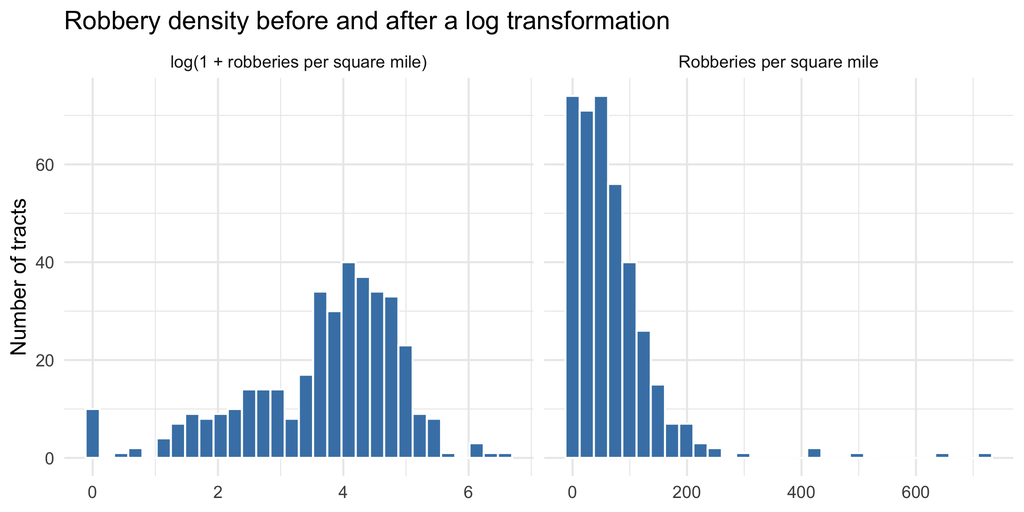

```r
tracts %>% st_drop_geometry() %>%
  transmute(`Robberies per square mile` = robbery_per_sqmi,
            `log(1 + robberies per square mile)` = log1p(robbery_per_sqmi)) %>%
  pivot_longer(everything(), names_to = "scale", values_to = "value") %>%
  ggplot(aes(x = value)) +
  geom_histogram(bins = 30, fill = "steelblue", color = "white") +
  facet_wrap(~scale, scales = "free_x") +
  labs(title = "Robbery density before and after a log transformation",
       x = NULL, y = "Number of tracts")
```

```r
f7 <- update(f6, . ~ . - robbery_per_sqmi + log1p(robbery_per_sqmi))
m_log <- lm(f7, data = tracts)
log_beta <- unname(coef(m_log)["log1p(robbery_per_sqmi)"])
model_log <- model_log %>%
  add_row(model = "m7", added = "m6: log1p robbery density",
          cv_rmse = cv_rmse(f7, tracts), notes = "Compress the right tail; retain zeros")
```

The long right tail motivates `log1p()`, but RMSE rises from 9.62 to 9.82 points.

In `m7`, holding other predictors constant, increasing robbery density from 10 to 11 per square mile changes predicted no-vehicle share by **0.217 percentage points**, using $\hat\beta[\log(12)-\log(11)]$.

### 5B: A squared term for centrality

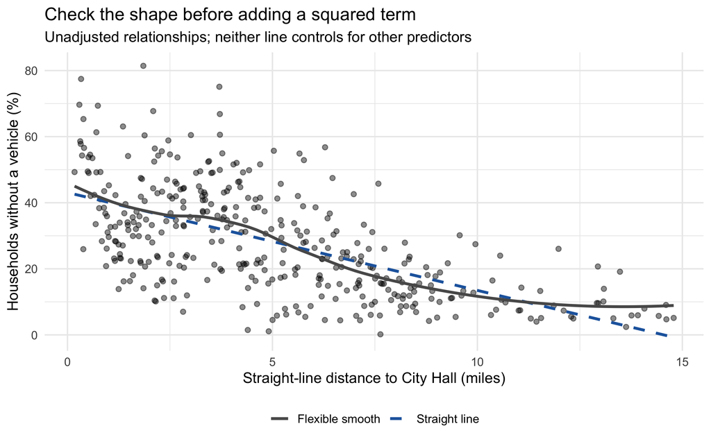

```r
ggplot(tracts, aes(x = dist_ch_mi, y = y)) +
  geom_point(alpha = 0.45) +
  geom_smooth(aes(color = "Straight line", linetype = "Straight line"),
              method = "lm", se = FALSE) +
  geom_smooth(aes(color = "Flexible smooth", linetype = "Flexible smooth"),
              method = "loess", se = FALSE) +
  scale_color_manual(values = c("Straight line" = "#2166ac",
                                "Flexible smooth" = "grey35")) +
  scale_linetype_manual(values = c("Straight line" = "dashed",
                                   "Flexible smooth" = "solid")) +
  theme(legend.position = "bottom") +
  labs(title = "Check the shape before adding a squared term",
       subtitle = "Unadjusted relationships; neither line controls for other predictors",
       x = "Straight-line distance to City Hall (miles)",
       y = "Households without a vehicle (%)", color = NULL, linetype = NULL)
```

```r
f8 <- update(f6, . ~ . + I(dist_ch_mi^2))
m_sq <- lm(f8, data = tracts)
turn_m8 <- -coef(m_sq)["dist_ch_mi"] / (2 * coef(m_sq)["I(dist_ch_mi^2)"])
model_log <- model_log %>%
  add_row(model = "m8", added = "m6 + squared City Hall distance",
          cv_rmse = cv_rmse(f8, tracts), notes = "Allow the distance gradient to bend")
```

The curved smooth motivates a squared term, which lowers RMSE from 9.62 to **9.34 points**. The conditional slope is $\hat\beta_1 + 2\hat\beta_2 d$: the negative linear and positive squared coefficients imply a decline followed by a rise.

### 5C: Categorical distance rings

The central–outer pattern motivates distance bands, using the template’s two- and five-mile cutoffs.

```r
tracts <- tracts %>%
  mutate(ring = case_when(dist_ch_mi < 2 ~ "Core",
                          dist_ch_mi < 5 ~ "Inner",
                          TRUE ~ "Outer"),
         ring = factor(ring, levels = c("Core", "Inner", "Outer")))
tracts %>% st_drop_geometry() %>% count(ring)
```

```
   ring   n
1  Core  79
2 Inner 134
3 Outer 168
```

```r
stopifnot(all(table(tracts$ring) >= 20))

# A large full-sample group does not by itself guarantee training-fold coverage.
ring_fold_counts <- imap_dfr(folds, function(idx, fold_name) {
  tibble(fold = fold_name, ring = levels(tracts$ring),
         n_train = as.integer(table(tracts$ring[idx])))
})
ring_fold_counts %>% group_by(ring) %>%
  summarize(min_train = min(n_train), max_train = max(n_train), .groups = "drop") %>%
  knitr::kable()
```

| ring | min_train | max_train |
| --- | --- | --- |
| Core | 67 | 76 |
| Inner | 114 | 126 |
| Outer | 148 | 155 |

```r
stopifnot(all(ring_fold_counts$n_train > 0))

f9 <- update(f6, . ~ . - dist_ch_mi + ring)
m_cat <- lm(f9, data = tracts)
summary(m_cat)
```

```
Call:
lm(formula = f9, data = tracts)

Residuals:
     Min       1Q   Median       3Q      Max
-27.9822  -5.9846  -0.7363   5.5734  30.0086

Coefficients:
                    Estimate Std. Error t value Pr(>|t|)
(Intercept)        44.601428   5.225060   8.536 3.61e-16 ***
income_10k         -2.047044   0.307013  -6.668 9.45e-11 ***
pct_renter          0.199043   0.035422   5.619 3.77e-08 ***
pct_ba              0.008251   0.047707   0.173   0.8628
hh_size            -2.603431   1.446570  -1.800   0.0727 .
robbery_per_sqmi    0.050444   0.007901   6.385 5.14e-10 ***
sidewalk_per_sqmi   0.003422   0.009578   0.357   0.7211
dist_sidewalk_mi   -1.349214   5.148394  -0.262   0.7934
ringInner          -7.920252   1.841753  -4.300 2.18e-05 ***
ringOuter         -16.671934   2.009976  -8.295 2.04e-15 ***
---
Signif. codes:  0 '***' 0.001 '**' 0.01 '*' 0.05 '.' 0.1 ' ' 1

Residual standard error: 9.656 on 371 degrees of freedom
Multiple R-squared:  0.6572,    Adjusted R-squared:  0.6488
F-statistic: 79.02 on 9 and 371 DF,  p-value: < 2.2e-16
```

```r
model_log <- model_log %>%
  add_row(model = "m9", added = "m6: replace linear distance with rings",
          cv_rmse = cv_rmse(f9, tracts), notes = "Core is the reference category")
```

Core, Inner, and Outer contain **79, 134, and 168 tracts**, respectively; every training fold contains all three levels. RMSE rises to 9.81 points, suggesting that the bands lose useful within-ring variation.

### 5D: Combine and compare

```r
f10 <- update(f7, . ~ . + I(dist_ch_mi^2))
model_log <- model_log %>%
  add_row(model = "m10", added = "m7 + squared City Hall distance",
          cv_rmse = cv_rmse(f10, tracts), notes = "Test log and quadratic together")
model_log %>% knitr::kable(digits = 3)
```

| model | added | cv_rmse | notes |
| --- | --- | --- | --- |
| m1 | Four ACS predictors | 12.327 | Baseline |
| m2 | m1 + robbery count | 11.758 | Raw event count |
| m3 | m2: replace count with area density | 10.861 | Separate size from concentration |
| m4 | m3 + sidewalk-request density | 10.748 | Pedestrian-environment proxy |
| m5 | m4 + nearest sidewalk-request distance | 10.683 | Straight-line distance from interior point |
| m6 | m5 + distance to City Hall | 9.618 | Centrality proxy |
| m7 | m6: log1p robbery density | 9.815 | Compress the right tail; retain zeros |
| m8 | m6 + squared City Hall distance | 9.340 | Allow the distance gradient to bend |
| m9 | m6: replace linear distance with rings | 9.811 | Core is the reference category |
| m10 | m7 + squared City Hall distance | 9.481 | Test log and quadratic together |

Squared distance helps most. Combining it with logged robbery density gives 9.48 points, versus 9.34 with raw density, so I retain the quadratic and raw density. In the categorical model, holding other predictors constant, an Outer tract has a predicted no-vehicle share **16.67 percentage points lower than Core**, the reference category.

## Part 6: Final model

### Choose a parsimonious combination

I test whether the sidewalk features still help after adding squared distance.

```r
f11 <- update(f8, . ~ . - dist_sidewalk_mi)
model_log <- model_log %>%
  add_row(model = "m11", added = "m8: remove nearest-request distance",
          cv_rmse = cv_rmse(f11, tracts), notes = "Almost unchanged RMSE")

f12 <- update(f11, . ~ . - sidewalk_per_sqmi)
model_log <- model_log %>%
  add_row(model = "m12", added = "m11: remove sidewalk-request density",
          cv_rmse = cv_rmse(f12, tracts), notes = "Lowest candidate RMSE; fewer terms")

f_final <- y ~ income_10k + pct_renter + pct_ba + hh_size +
  robbery_per_sqmi + dist_ch_mi + I(dist_ch_mi^2)
m_final <- lm(f_final, data = tracts)
summary(m_final)
```

```
Call:
lm(formula = f_final, data = tracts)

Residuals:
     Min       1Q   Median       3Q      Max
-24.6726  -5.8527  -0.2969   5.5462  29.5997

Coefficients:
                 Estimate Std. Error t value Pr(>|t|)
(Intercept)      53.01491    4.99282  10.618  < 2e-16 ***
income_10k       -1.93785    0.29726  -6.519 2.30e-10 ***
pct_renter        0.18152    0.03377   5.374 1.36e-07 ***
pct_ba           -0.02366    0.04494  -0.527   0.5988
hh_size          -2.39212    1.38655  -1.725   0.0853 .
robbery_per_sqmi  0.04034    0.00724   5.572 4.82e-08 ***
dist_ch_mi       -4.97386    0.58739  -8.468 5.82e-16 ***
I(dist_ch_mi^2)   0.21898    0.04042   5.418 1.08e-07 ***
---
Signif. codes:  0 '***' 0.001 '**' 0.01 '*' 0.05 '.' 0.1 ' ' 1

Residual standard error: 9.249 on 373 degrees of freedom
Multiple R-squared:  0.6838,    Adjusted R-squared:  0.6778
F-statistic: 115.2 on 7 and 373 DF,  p-value: < 2.2e-16
```

```r
model_log <- model_log %>%
  add_row(model = "final", added = "Retain m12",
          cv_rmse = cv_rmse(f_final, tracts), notes = "Selected candidate, not a new test")

model_log %>%
  gt() %>% fmt_number(columns = cv_rmse, decimals = 3) %>%
  cols_label(model = "Model", added = "Change / comparison",
             cv_rmse = "CV RMSE (pp)", notes = "Reason / observation") %>%
  tab_header(title = "Model log: every candidate on the same 381 tracts",
             subtitle = "Mean RMSE across the same ten folds; lower is better")
```

Model log: every candidate on the same 381 tracts

Mean RMSE across the same ten folds; lower is better

| Model | Change / comparison | CV RMSE (pp) | Reason / observation |
| --- | --- | --- | --- |
| m1 | Four ACS predictors | 12.327 | Baseline |
| m2 | m1 + robbery count | 11.758 | Raw event count |
| m3 | m2: replace count with area density | 10.861 | Separate size from concentration |
| m4 | m3 + sidewalk-request density | 10.748 | Pedestrian-environment proxy |
| m5 | m4 + nearest sidewalk-request distance | 10.683 | Straight-line distance from interior point |
| m6 | m5 + distance to City Hall | 9.618 | Centrality proxy |
| m7 | m6: log1p robbery density | 9.815 | Compress the right tail; retain zeros |
| m8 | m6 + squared City Hall distance | 9.340 | Allow the distance gradient to bend |
| m9 | m6: replace linear distance with rings | 9.811 | Core is the reference category |
| m10 | m7 + squared City Hall distance | 9.481 | Test log and quadratic together |
| m11 | m8: remove nearest-request distance | 9.344 | Almost unchanged RMSE |
| m12 | m11: remove sidewalk-request density | 9.315 | Lowest candidate RMSE; fewer terms |
| final | Retain m12 | 9.315 | Selected candidate, not a new test |

Removing both sidewalk terms gives **9.32 points**, improving on baseline by **3.01 points (24.4%)**. Its 0.02-point advantage over `m8` is negligible; I select it for comparable performance with fewer terms.

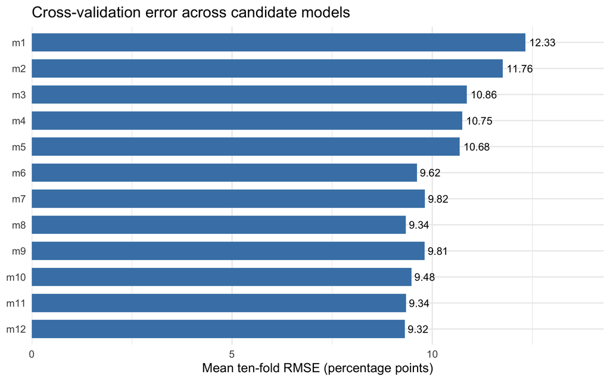

```r
model_log %>% filter(model != "final") %>%
  mutate(model = factor(model, levels = rev(model))) %>%
  ggplot(aes(x = cv_rmse, y = model)) +
  geom_col(fill = "steelblue", width = 0.7) +
  geom_text(aes(label = sprintf("%.2f", cv_rmse)), hjust = -0.15, size = 3.5) +
  scale_x_continuous(limits = c(0, 14), expand = expansion(mult = c(0, 0.02))) +
  labs(title = "Cross-validation error across candidate models",
       x = "Mean ten-fold RMSE (percentage points)", y = NULL)
```

### Final distance curve

```r
b1 <- unname(coef(m_final)["dist_ch_mi"])
b2 <- unname(coef(m_final)["I(dist_ch_mi^2)"])
turn_final <- -b1 / (2 * b2)
distance_range <- range(tracts$dist_ch_mi)

tibble(min_miles = distance_range[1], max_miles = distance_range[2],
       turning_point_miles = turn_final,
       turning_point_in_range = between(turn_final, distance_range[1], distance_range[2]),
       tracts_beyond_turn = sum(tracts$dist_ch_mi > turn_final)) %>%
  knitr::kable(digits = 2)
```

| min_miles | max_miles | turning_point_miles | turning_point_in_range | tracts_beyond_turn |
| --- | --- | --- | --- | --- |
| 0.17 | 14.79 | 11.36 | TRUE | 23 |

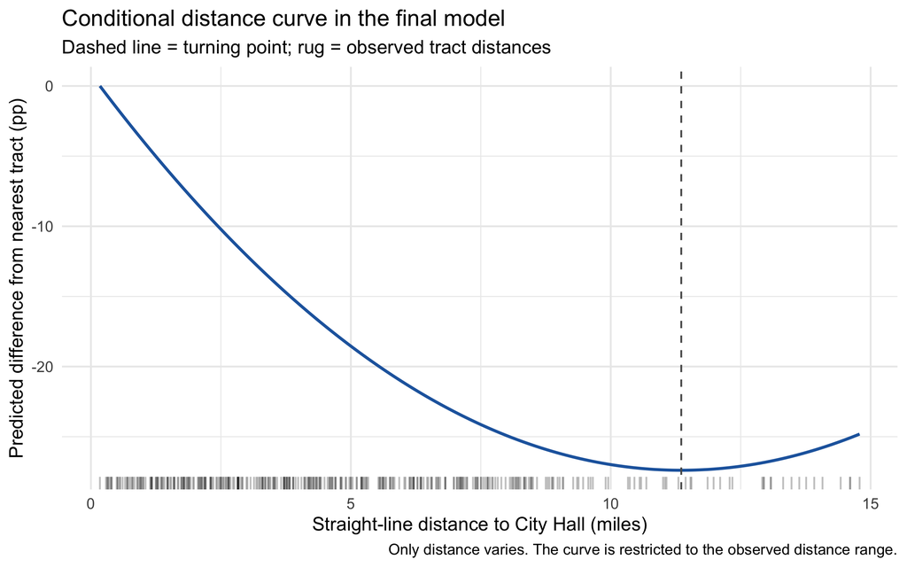

```r
# Plot only the fitted distance contribution, relative to the nearest tract.
# Other predictors are held constant; these are differences, not predicted levels.
distance_curve <- tibble(d = seq(distance_range[1], distance_range[2], length.out = 200)) %>%
  mutate(change_pp = b1 * (d - distance_range[1]) +
           b2 * (d^2 - distance_range[1]^2))
ggplot(distance_curve, aes(x = d, y = change_pp)) +
  geom_line(color = "#2166ac", linewidth = 0.9) +
  geom_vline(xintercept = turn_final, linetype = "dashed", color = "grey35") +
  geom_rug(data = st_drop_geometry(tracts), aes(x = dist_ch_mi),
           inherit.aes = FALSE, alpha = 0.25) +
  labs(title = "Conditional distance curve in the final model",
       subtitle = "Dashed line = turning point; rug = observed tract distances",
       x = "Straight-line distance to City Hall (miles)",
       y = "Predicted difference from nearest tract (pp)",
       caption = "Only distance varies. The curve is restricted to the observed distance range.")
```

The turning point is **11.36 miles**, within the observed **0.17–14.79 mile** range. Only **23 tracts** lie beyond it, so the upturn has limited support and should not be extrapolated.

### Where is the final model wrong?

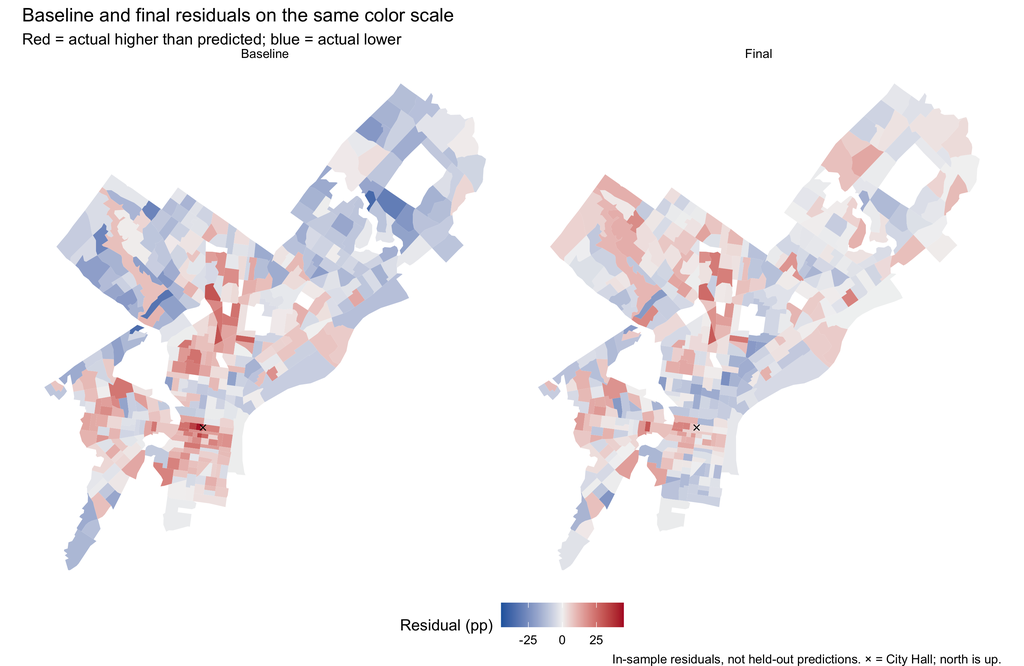

```r
tracts <- tracts %>% mutate(resid_final = residuals(m_final))
residual_maps <- tracts %>% select(GEOID, resid_m1, resid_final) %>%
  pivot_longer(starts_with("resid"), names_to = "model", values_to = "residual") %>%
  mutate(model = factor(model, levels = c("resid_m1", "resid_final"),
                        labels = c("Baseline", "Final")))

ggplot(residual_maps) +
  geom_sf(aes(fill = residual), color = NA) +
  geom_sf(data = city_hall, shape = 4, size = 1.6, inherit.aes = FALSE) +
  facet_wrap(~model) +
  scale_fill_gradient2(low = "#2166ac", mid = "grey95", high = "#b2182b",
                       midpoint = 0, limits = c(-45, 45)) +
  theme_void() + theme(legend.position = "bottom") +
  labs(title = "Baseline and final residuals on the same color scale",
       subtitle = "Red = actual higher than predicted; blue = actual lower",
       fill = "Residual (pp)",
       caption = "In-sample residuals, not held-out predictions. × = City Hall; north is up.")
```

Center City underprediction and Northeast overprediction shrink: tract 4.03 improves from +43.28 to +7.62 points, and tract 345.01 from −36.49 to −15.96. Underprediction remains in parts of North and West Philadelphia. These are in-sample residuals.

### Are the biggest misses in the least reliable tracts?

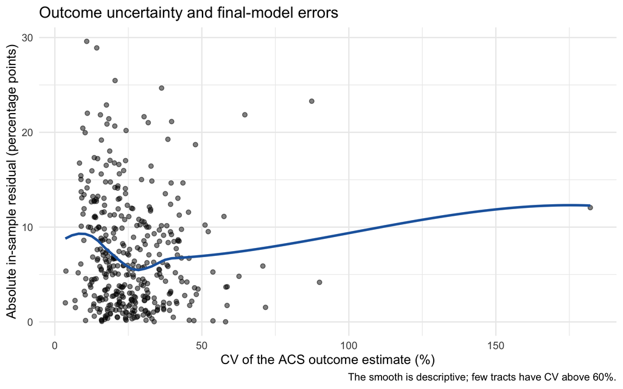

```r
ggplot(tracts, aes(x = y_cv, y = abs(resid_final))) +
  geom_point(alpha = 0.5) +
  geom_smooth(method = "loess", se = FALSE, color = "#2166ac") +
  labs(title = "Outcome uncertainty and final-model errors",
       x = "CV of the ACS outcome estimate (%)",
       y = "Absolute in-sample residual (percentage points)",
       caption = "The smooth is descriptive; few tracts have CV above 60%.")
```

```r
tracts %>% st_drop_geometry() %>%
  group_by(reliability) %>%
  summarize(tracts = n(), mean_abs_residual = mean(abs(resid_final)),
            median_abs_residual = median(abs(resid_final)), .groups = "drop") %>%
  knitr::kable(digits = 2)
```

| reliability | tracts | mean_abs_residual | median_abs_residual |
| --- | --- | --- | --- |
| High | 28 | 10.63 | 10.74 |
| Low | 45 | 6.67 | 5.19 |
| Moderate | 308 | 6.81 | 5.56 |

```r
tracts %>% st_drop_geometry() %>% arrange(desc(abs(resid_final))) %>%
  transmute(tract = sub(";.*", "", NAME), actual_pct = y,
            moe_pp = y_moe, cv_pct = y_cv, residual_pp = resid_final) %>%
  slice_head(n = 5) %>% knitr::kable(digits = 2)
```

| tract | actual_pct | moe_pp | cv_pct | residual_pp |
| --- | --- | --- | --- | --- |
| Census Tract 88.01 | 81.43 | 14.52 | 10.84 | 29.60 |
| Census Tract 200 | 75.10 | 17.61 | 14.25 | 28.91 |
| Census Tract 280 | 55.72 | 18.78 | 20.49 | 25.46 |
| Census Tract 156 | 10.14 | 6.06 | 36.31 | -24.67 |
| Census Tract 61 | 1.48 | 2.13 | 87.37 | -23.29 |

CV and absolute residual have correlation **-0.05**; several large misses have High or Moderate reliability. The median outcome standard error is **5.50 points**, but this plot cannot isolate the share of error due to sampling noise.

### Validation and limits

```r
# Reuse the exact folds to inspect held-out predictions and verify row coverage.
set.seed(5080)
cv_baseline <- train(f1, data = st_drop_geometry(tracts), method = "lm",
                     trControl = ctrl)
set.seed(5080)
cv_final <- train(f_final, data = st_drop_geometry(tracts), method = "lm",
                  trControl = ctrl)

stopifnot(identical(tracts$GEOID, model_geoids),
          identical(cv_baseline$control$index, cv_final$control$index),
          nobs(m1) == nrow(tracts), nobs(m_final) == nrow(tracts),
          nrow(cv_final$pred) == nrow(tracts),
          !anyDuplicated(cv_final$pred$rowIndex),
          all(is.finite(model.matrix(f_final, st_drop_geometry(tracts)))),
          all(is.finite(cv_final$pred$pred)))

tibble(
  model = c("Baseline", "Final"),
  mean_fold_RMSE = c(cv_baseline$results$RMSE, cv_final$results$RMSE),
  pooled_OOF_RMSE = c(sqrt(mean((cv_baseline$pred$obs - cv_baseline$pred$pred)^2)),
                      sqrt(mean((cv_final$pred$obs - cv_final$pred$pred)^2)))
) %>% knitr::kable(digits = 3)
```

| model | mean_fold_RMSE | pooled_OOF_RMSE |
| --- | --- | --- |
| Baseline | 12.327 | 12.412 |
| Final | 9.315 | 9.390 |

```r
# Save compact audit outputs alongside the original API responses.
write_csv(model_log, file.path(data_dir, "model_log.csv"))
write_csv(geometry_audit, file.path(data_dir, "geometry_audit.csv"))
tracts %>% st_drop_geometry() %>%
  select(GEOID, y, y_moe, y_cv, income_10k, pct_renter, pct_ba, hh_size,
         n_robbery, area_sqmi, robbery_per_sqmi, n_sidewalk, sidewalk_per_sqmi,
         dist_sidewalk_mi, dist_ch_mi, ring, resid_m1, resid_final) %>%
  write_csv(file.path(data_dir, "model_data.csv"))
tibble(GEOID = model_geoids[cv_final$pred$rowIndex],
       fold = cv_final$pred$Resample, observed = cv_final$pred$obs,
       predicted = cv_final$pred$pred) %>%
  write_csv(file.path(data_dir, "out_of_fold_predictions.csv"))
```

The log uses mean fold RMSE; pooled RMSE aggregates all held-out squared errors first. Reusing random folds for model selection may overstate performance, especially with spatially related tracts.

The final model has **7 negative fitted values** and **8 negative held-out predictions**. Scores use these unmodified predictions; a bounded model is a possible next step.

## Part 7: Reflection

Robbery density was the most useful open-data feature. Adding it to the ACS baseline reduced CV RMSE from 12.33 to 10.86 percentage points, a 1.47-point improvement. Normalizing by area helps separate incident concentration from tract size. Distance to City Hall then absorbed part of the central-versus-peripheral pattern, and its squared term improved the linear-distance model from 9.62 to 9.34. These features may capture overlapping aspects of density, accessibility, and neighborhood conditions; their performance does not identify a causal mechanism.

The sidewalk features disappointed me. Their initial gains were small, and removing both from the quadratic model gave a slightly lower RMSE of 9.32. Complaints depend on reporting and may add little beyond centrality. Logging robbery density also worsened prediction, despite making the histogram less skewed.

**β̂ reading:** Holding the other final-model terms constant, a one-percentage-point higher renter share is associated with about 0.18 percentage points more households without a vehicle. **ŷ reading:** If two tracts have identical values for the other predictors, increasing renter share by ten percentage points raises the model’s predicted no-vehicle share by about 1.82 points.

The final map still underpredicts some North and West Philadelphia tracts. I would next measure transit service frequency and walking access using historical 2023 SEPTA GTFS schedules, checking archive coverage before using them. Distance to City Hall cannot represent route quality, transfers, or physical barriers.

Finally, the uncertainty plot does not show a simple increase in error with CV: several large misses have reasonably reliable ACS estimates. A median outcome standard error of 5.50 points indicates meaningful noise, but it cannot be subtracted from RMSE to isolate model error. Sampling uncertainty, omitted variables, and imperfect functional form all remain plausible. The 24.4% improvement is encouraging, but reused random folds and a few negative predictions limit immediate policy use.